# morpho diversification

Gaurav Kandlikar

November 9, 2015

### Simulating Browning Motion evolution

We can simulate BM trait evolution by drawing random numbers from a normal distribution and generating their cumulative sum.

```r
library(geiger); library(wesanderson)
```

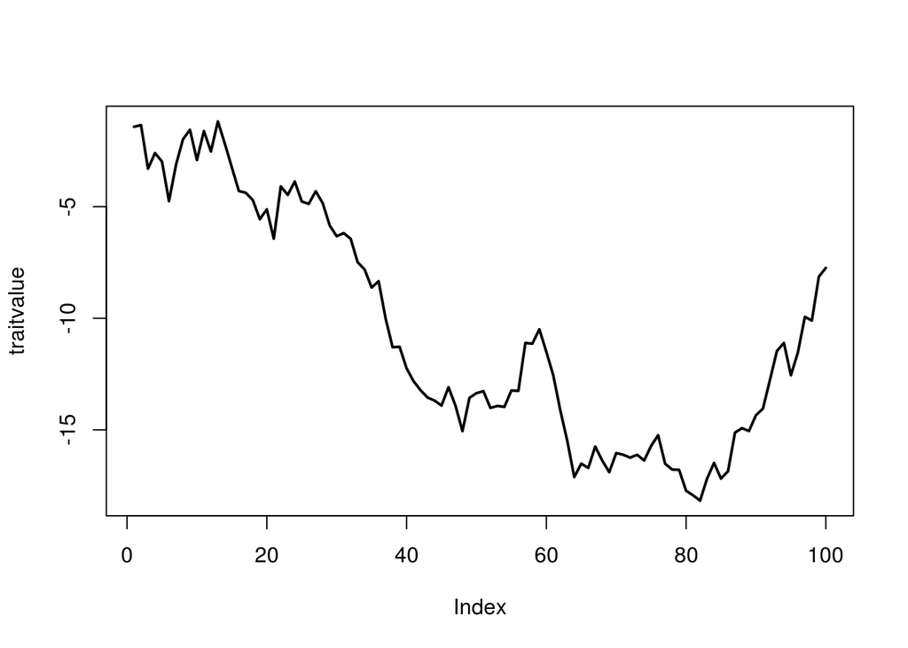

```r
num_generations <- 100
displace <- rnorm(num_generations)

traitvalue <- cumsum(displace)

plot(traitvalue, lwd = 2, type = "l")
```

## Exercise 1

Now let’s imagine we have 50 independent lineages that all start out with the same value of a continuous trait. If we let those 50 lineages evolve under Brownian motion (BM) what is the expected pattern of their trait values after 100 time units?

> The expected value is 0 (starting value), with a variance proportional to the length of time.

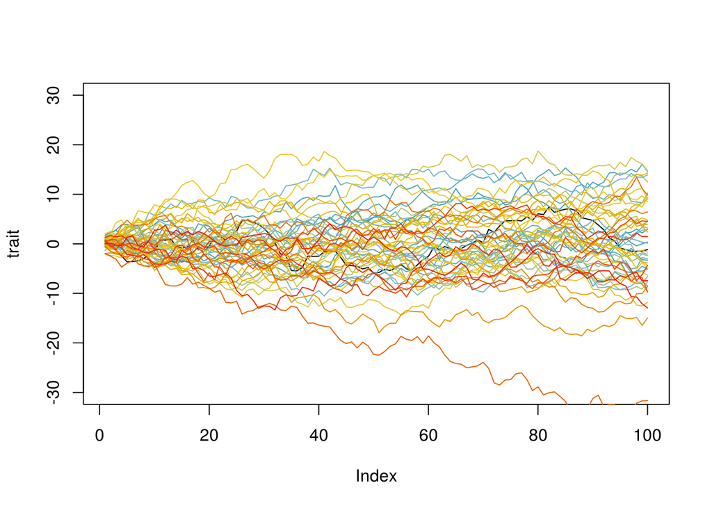

```r
num_lineages <- 50
colors <- wes_palette("Zissou", n = num_lineages, type = "continuous")
plot(cumsum(rnorm(100)), type="l", ylim=c(-30,30), ylab = "trait")
for(i in 1:num_lineages) {lines(cumsum(rnorm(100)), col = colors[i])}
```

## Exercise 2

Write an R block that plots Brownian evolution for 50 independent lineages for 50 time units side by side with BM for 100 time units. What is the effect of time on the diversity in trait values you see in those simulations? How does time affect diversity under BM?

```r
num_lineages <- 50
colors <- wes_palette("Darjeeling", n = num_lineages, type = "continuous")

par(mar = c(5,4,4,2)+0.1)
layout(matrix (c(1, 2, 2), 1, 2, byrow = T))
```

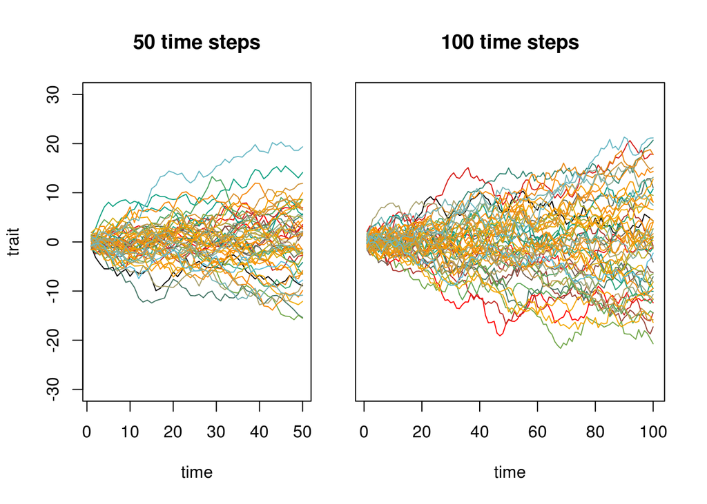

```r
# layout.show(n = 2)
plot(cumsum(rnorm(50)), type="l", ylim=c(-30,30), ylab = "trait", main = "50 time steps", xlab = "time")
for(i in 1:num_lineages) {lines(cumsum(rnorm(50)), col = colors[i])}

par(mar = c(5, 0, 4, 2) + 0.1)
plot(cumsum(rnorm(100)), type="l", ylim=c(-30,30), ylab = "trait", yaxt = "n", main = "100 time steps", xlab = "time")
for(i in 1:num_lineages) {lines(cumsum(rnorm(100)), col = colors[i])}
```

### Varying rates of evolution

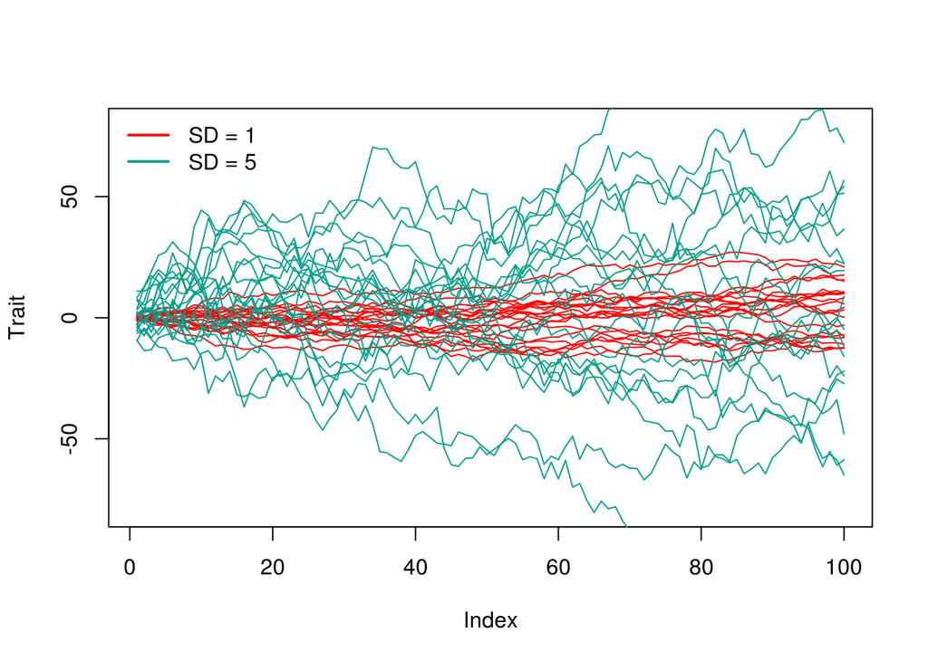

```r
colors <- wes_palette("Darjeeling", n = 2)
par(mfrow = c(1,1), mar = c(5,4,4,2)+0.1)
plot(cumsum(rnorm(100)), type="l", ylim=c(-80,80), ylab="Trait", col=colors[1])
for(i in 1:20) lines(cumsum(rnorm(100)), col=colors[1])
for(i in 1:20) lines(cumsum(rnorm(100, sd=5)), col=colors[2])
legend("topleft", col = colors, legend = c("SD = 1", "SD = 5"), lwd = 2, bty = "n")
```

## Exercise 3

What is the rate parameter of Brownian motion? How does trait variance in a clade evolving under BM scale with rate?

> There appears to be an exponential increase in population variance with sigma^2:

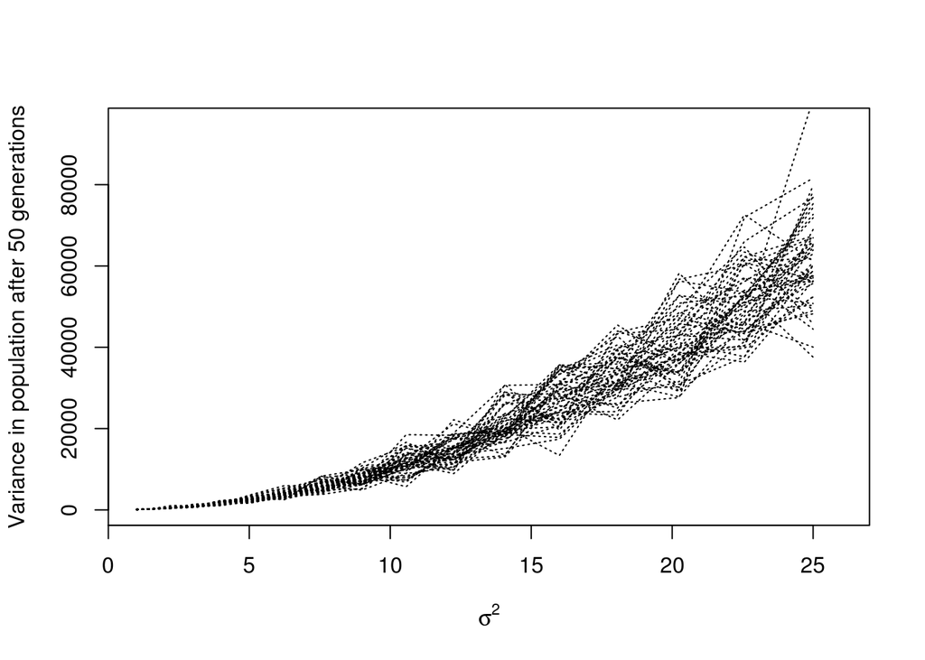

```r
sigmas <- seq(from = 1, to = 5, by = 0.25)

timesteps <- 100
variances <- numeric(length(sigmas))
lineages <- seq(from = 1, to = 50)
lineage_final <- numeric(length(lineages))

plot(1, type = "n", xlim = c(1, max(sigmas)^2+1), ylim = c(0, 95000), xlab = bquote(sigma^2), ylab = "Variance in population after 50 generations")

for(j in 1:50) {

  # Crappy way to do this with a loop:
  #   for (i in 1:length(sigmas)) {
  #     lineage_final <- sapply(lineages, function(x) cumsum(rnorm(timesteps+1, sd = sigmas[i]^2))[timesteps+1])
  #     variances[i] <- var(lineage_final)
  #   }

  # Slicker way of doing this with an apply function
  variances <- sapply(sigmas, function(x) var(sapply(lineages, function (y) cumsum(rnorm(timesteps+1, sd = x^2))[timesteps+1])))

  lines(x = sigmas^2, y = variances, lwd = 1, lty = 3)
}
```

### Simulating traits on trees

See below that polar bears and grizzlies diverged from one another 1 MY ago while spectacled bears have evolved independently from that clade for 5 million years. Think about what this tree implies about the evolution of a continuous trait.  
> This implies that Spectacled bears have had longer to evolve independently away from polar+grizzlybear- so the latter two should be fairly similar to one another, while the spectacled bear might be much different

Node 4, the root of the tree, represents the common ancestor of all three bears. Let’s imagine we are interested in simulating the evolution of body size from this common ancestor. If the ancestral value was 250 kg we could simulate one outcome of BM from node 4 to spectacled bear by drawing one “walk” away with a step size that is determined by both the sigma^2 (the Brownian rate) and time. To get the correct standard deviation for multiple time steps at once we simple take the square root of the product of time X sigma^2. See the example below:

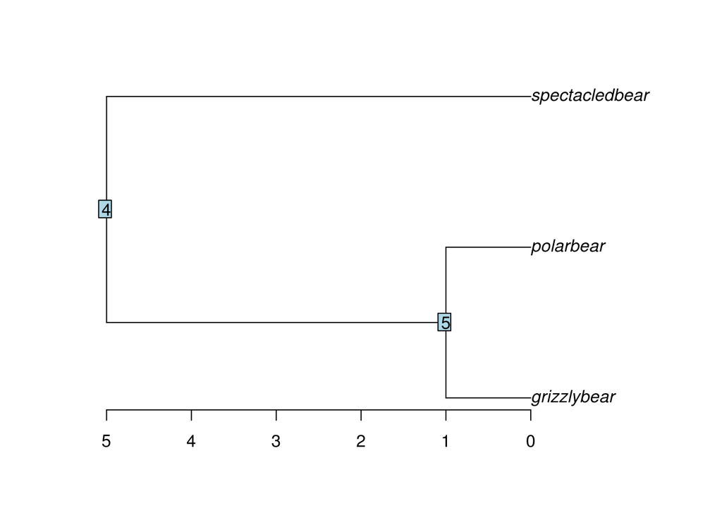

```r
tree<-read.tree(text="((grizzlybear:1, polarbear:1):4, spectacledbear:5);")
plot(tree)
nodelabels()
axisPhylo()
```

```r
rootMass <- 250 # size of ancestor
sigmasq = 2.5 # Brownian rate
time = 5 # 5 million years of independent evolution from the root
sd <- sqrt(time * sigmasq) # Brownian evolution is proportional to rate X time)
specbearDeltaMass <- rnorm(1, mean = 0, sd = sd)
specbearMass <- rootMass + specbearDeltaMass
specbearMass
```

```
## [1] 246.5635
```

```r
# Another way to do this using the tree structure itself to supply the time argument
# Tree tip labels are numbered from top to bottom, so in our tree
# spectacled bear = 1, polarbear = 2, and grizzly = 3
specbearDeltaMass<-rnorm(1, mean = 0, sd = sqrt(sigmasq*tree$edge.length[1]))
# NOTE: I am not sure this works- tree$edge.length[1] == 4, not 5 as it should be for specbear!
specbearMass <- rootMass + specbearDeltaMass
specbearMass
```

```
## [1] 254.657
```

## Exercise 4.

Write a block of R code that simulate BM evolution for this three taxon tree. You can do this as a series of steps or write a general function.

```r
# Trying to write a general function but not set on how to go about this best
# simulate_trait <- function(phy, node_trait, bmrate) {
#   # Simulate BM on each branch
#   per_branch <- sapply(phy$edge.length, function(x) rnorm(1, mean = 0, sd = sqrt(bmrate*x)))
# }

specbearMass <- rootMass + rnorm(1, mean = 0, sd = sqrt(sigmasq*5))
node5mass <- rootMass + rnorm(1, mean = 0, sd = sqrt(sigmasq*4))
polarbearMass <- node5mass + rnorm(1, mean = 0, sd = sqrt(sigmasq*1))
grizzlybearMass <- node5mass + rnorm(1, mean = 0, sd = sqrt(sigmasq*1))
```

## Trends in trait evolution

What if we think that there has been a trend in the evolution of a trait? One way we could simulate this process is by saying that the mean of the normal distrbution is changing with time. We will do this by adding a new parameter to our model, mu. mu is going to shift the mean of the random normal distribution as a function of time (see the function below)

```r
# a function that requires
# mu which is the trend parameter showing how the mean of the normal distribution changes over time,
# time the length of the simulation and stdev the standard deviation of the normal distribution,
# it assumes the starting ancestral trait value is 0

bmtrend <- function(time, mu, stdev){
  displace <- vector(length=time)
    for(i in 1:time){
      # sample from rnorm with a mean with a mean of mu multiplied by the iteration
      displace[i]<-rnorm(1, mean=mu*i, sd=stdev)
    }
  traj<-cumsum(displace)
  return(traj)
}
```

Now we are going to run this bmtrend function 10 times using the replicate function, once with a mu of 0.02 and the other with mu=-0.02

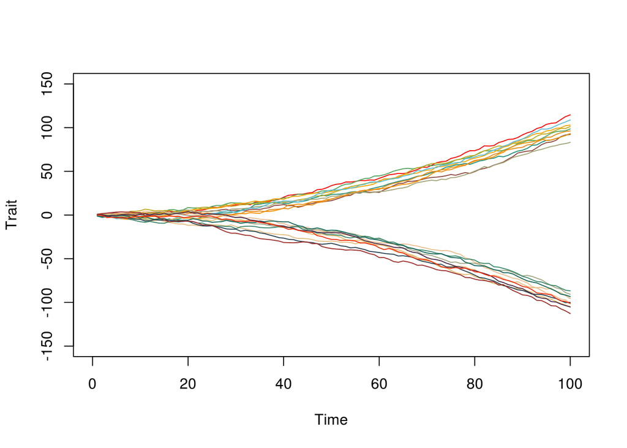

```r
par(mfrow = c(1,1))
bmtrend0.02 <- replicate(10, bmtrend(100, 0.02, 1))
bmtrendneg0.02 <- replicate(10, bmtrend(100, -0.02, 1))

cols1 <- wes_palette("Darjeeling", n = 10, type = "continuous")
cols2 <- wes_palette("Rushmore", n = 10, type = "continuous")

plot(bmtrend0.02[,1], xlim=c(0,100), ylim=c(-150, 150),
     type="l", col=cols1[1], xlab="Time", ylab="Trait")
for(i in 2:10) lines(bmtrend0.02[,i], col=cols1[i])
for(i in 1:10) lines(bmtrendneg0.02[,i], col=cols2[i])
```

## Exercise 5.

Simulate 15 runs of a trend process for two groups of species: one with a mu of 0.5 and and the other with a mu of -0.5 for 100 MY. If you were to measure trait diversity in these groups at 100 only (in other words, if you did not knowm the true trait history) is there any information in those trait values that could distinguish evolution under a trend from regular Brownian evolution? Can you think of any additional information that would be helpful in distinguishing these models?